# ANOVA and linear models

Manpreet S. Katari

## Comparison of ANOVA with linear models

Let’s generate two sample groups, *ctrl* and *trt*, by taking random samples from normally distributed data.

First, Select 5 random numbers from distribution where *mean*=0 and *sd*=1

```r
ctrl=rnorm(5)
```

Select 5 random numbers from distribution where *mean*=5 and *sd*= 1

```r
trt = rnorm(5, mean=5)
```

combined both samples into one vector

```r
data = c(ctrl,trt)
```

Defined how the data is grouped

```r
expgroups = factor(rep(c("ctrl", "trt"), each=5))
```

Use boxplot to show distribution

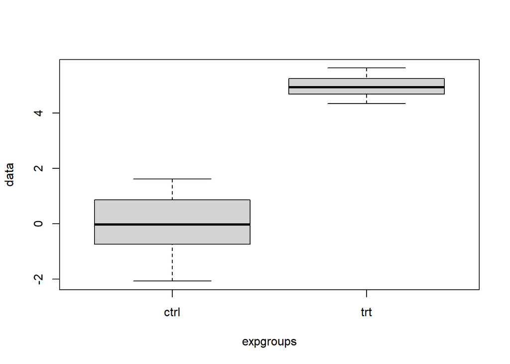

```r
boxplot(data ~ expgroups)
```

## Perform ANOVA

The model is written such that the dependent variable (data) is explained by the independent variable (groups). Two ways to perform an ANOVA analysis is to use either the `aov()` function or the `lm()` function.

Method 1: `aov`

```r
summary(aov(data~expgroups))
```

```
##             Df Sum Sq Mean Sq F value   Pr(>F)
## expgroups    1  63.50   63.50    55.4 7.31e-05 ***
## Residuals    8   9.17    1.15
## ---
## Signif. codes:  0 '***' 0.001 '**' 0.01 '*' 0.05 '.' 0.1 ' ' 1
```

The report tells us that the SSB is ~60, and the SSW ~10 If the SSB/SSW = SumSq(expgroups)/SumSq(Residuals) is a lot different from 1, we can conclude that there is a difference between the groups. But we actually want the F-statistic = (SSB/df.exp) / (SSW/df.res) = SSB/1 / SSW/8

Method 2: `lm()`

```r
datalm = lm(data ~ expgroups) # linear model of the data as explained by expgroups
                              # expgroups is the independent variable
                              # data is the dependent variable
summary(datalm)
```

```
##
## Call:
## lm(formula = data ~ expgroups)
##
## Residuals:
##      Min       1Q   Median       3Q      Max
## -2.00143 -0.53799  0.00284  0.56385  1.68774
##
## Coefficients:
##              Estimate Std. Error t value Pr(>|t|)
## (Intercept)  -0.06678    0.47879  -0.139    0.893
## expgroupstrt  5.03985    0.67712   7.443 7.31e-05 ***
## ---
## Signif. codes:  0 '***' 0.001 '**' 0.01 '*' 0.05 '.' 0.1 ' ' 1
##
## Residual standard error: 1.071 on 8 degrees of freedom
## Multiple R-squared:  0.8738, Adjusted R-squared:  0.858
## F-statistic:  55.4 on 1 and 8 DF,  p-value: 7.312e-05
```

The results from looking at `summary.lm` and `summary.aov` are slightly different. The Null hypothesis of linear modeling is that the *slope* of the line is 0, whereas the Null hypothesis of the ANOVA is that the *variance* of all of the data is the same as the variance of the individual groups. In other words, the baseline for `lm` is the control, whereas for ANOVA there is no baseline; you simply look at all the differences between the groups.

Despite these methodological differences, **notice that the $p$-values are the same.**

Using the `anova()` function on the linear model gives you the same information as the summary of `aov()`

```r
anova(datalm)
```

```
## Analysis of Variance Table
##
## Response: data
##           Df Sum Sq Mean Sq F value    Pr(>F)
## expgroups  1  63.50  63.500    55.4 7.312e-05 ***
## Residuals  8   9.17   1.146
## ---
## Signif. codes:  0 '***' 0.001 '**' 0.01 '*' 0.05 '.' 0.1 ' ' 1
```

### Generating random normally distributed data for three groups

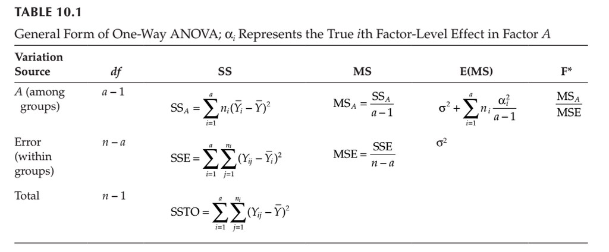

Let’s make another group and call it `trt2`.

```r
trt2= rnorm(5,mean=10) # same number of samples, but mean differs
```

Let’s combine it with the other groups.

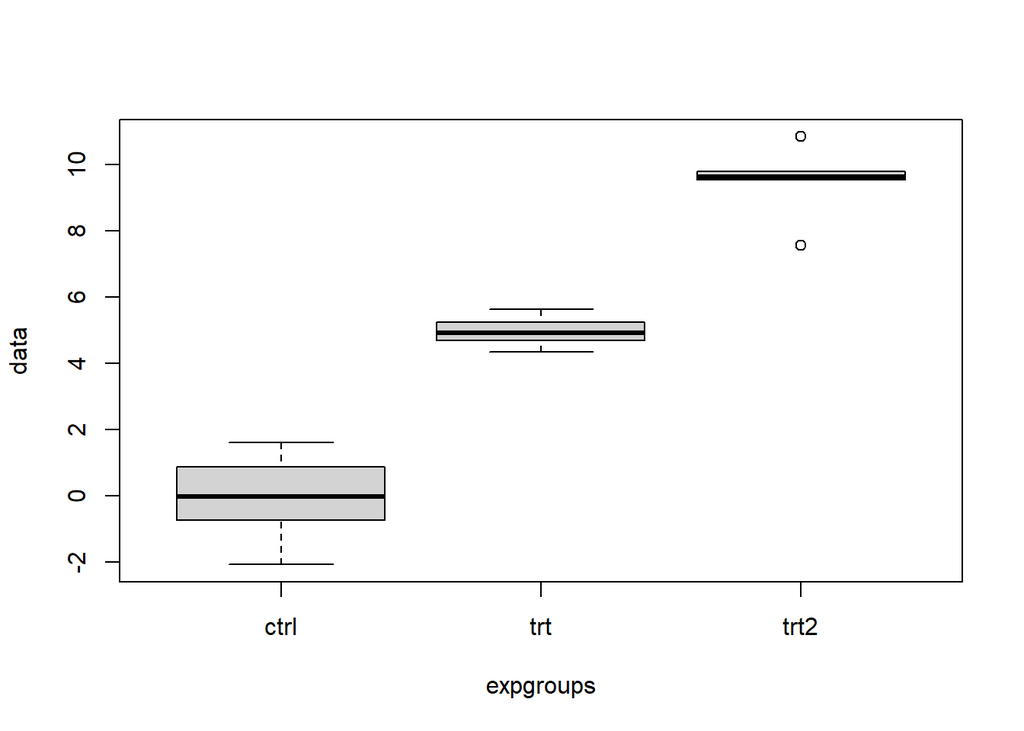

```r
data = c(ctrl,trt,trt2)
expgroups = factor(rep(c("ctrl", "trt", "trt2"), each=5))
boxplot(data ~ expgroups)
```

```r
datalm = lm(data ~ expgroups)
summary(datalm)
```

```
##
## Call:
## lm(formula = data ~ expgroups)
##
## Residuals:
##      Min       1Q   Median       3Q      Max
## -2.00143 -0.45083  0.06079  0.48624  1.68774
##
## Coefficients:
##               Estimate Std. Error t value Pr(>|t|)
## (Intercept)   -0.06678    0.49720  -0.134    0.895
## expgroupstrt   5.03985    0.70315   7.168 1.14e-05 ***
## expgroupstrt2  9.54489    0.70315  13.575 1.21e-08 ***
## ---
## Signif. codes:  0 '***' 0.001 '**' 0.01 '*' 0.05 '.' 0.1 ' ' 1
##
## Residual standard error: 1.112 on 12 degrees of freedom
## Multiple R-squared:  0.9389, Adjusted R-squared:  0.9287
## F-statistic: 92.23 on 2 and 12 DF,  p-value: 5.193e-08
```

For this model, “Estimate” gives the slope of the line between the control and each experimental group. This is around 5 comparing ctl-trt1 and ~10 comparing ctl-trt2. This is just the difference between the means.

We get p-values for the individual groups, and an overall p-value for the model.

Let’s compare this to the ANOVA result:

```r
summary(aov(data ~ expgroups))
```

```
##             Df Sum Sq Mean Sq F value   Pr(>F)
## expgroups    2 228.00  114.00   92.23 5.19e-08 ***
## Residuals   12  14.83    1.24
## ---
## Signif. codes:  0 '***' 0.001 '**' 0.01 '*' 0.05 '.' 0.1 ' ' 1
```

Notice that for `summary` we don’t see which groups are giving the significant difference. We can use “Tukey’s honest significant difference” test, **TukeyHSD**, which performs a pair-wise comparison to help us figure this out.

```r
TukeyHSD(aov(data ~ expgroups))
```

```
##   Tukey multiple comparisons of means
##     95% family-wise confidence level
##
## Fit: aov(formula = data ~ expgroups)
##
## $expgroups
##               diff      lwr       upr    p adj
## trt-ctrl  5.039847 3.163947  6.915747 3.14e-05
## trt2-ctrl 9.544891 7.668991 11.420791 0.00e+00
## trt2-trt  4.505044 2.629144  6.380945 9.25e-05
```

This shows the magnitude of the differences between all pairwise combinations of the groups, so you can tell which groups are responsible for any major differences between them.

Again, performing the `anova()` function on the linear model gives you the same results as the summary of `aov()` however you can not perform `TukeyHSD()` on the `anova()` results.

```r
anova(datalm)
```

```
## Analysis of Variance Table
##
## Response: data
##           Df  Sum Sq Mean Sq F value    Pr(>F)
## expgroups  2 228.001 114.000   92.23 5.193e-08 ***
## Residuals 12  14.832   1.236
## ---
## Signif. codes:  0 '***' 0.001 '**' 0.01 '*' 0.05 '.' 0.1 ' ' 1
```

### What if trt2 is the same as trt?

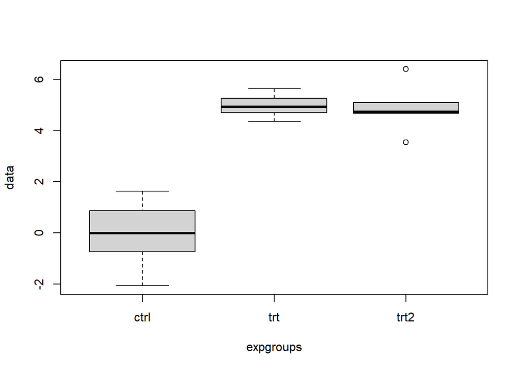

```r
trt2= rnorm(5,mean=5)
data = c(ctrl,trt,trt2)
expgroups = factor(rep(c("ctrl", "trt","trt2"), each=5))
datalm = lm(data ~ expgroups)
boxplot(data ~ expgroups)
```

```r
summary(datalm)
```

```
##
## Call:
## lm(formula = data ~ expgroups)
##
## Residuals:
##      Min       1Q   Median       3Q      Max
## -2.00143 -0.45083 -0.03947  0.47057  1.68774
##
## Coefficients:
##               Estimate Std. Error t value Pr(>|t|)
## (Intercept)   -0.06678    0.47252  -0.141     0.89
## expgroupstrt   5.03985    0.66825   7.542 6.84e-06 ***
## expgroupstrt2  4.95231    0.66825   7.411 8.15e-06 ***
## ---
## Signif. codes:  0 '***' 0.001 '**' 0.01 '*' 0.05 '.' 0.1 ' ' 1
##
## Residual standard error: 1.057 on 12 degrees of freedom
## Multiple R-squared:  0.8613, Adjusted R-squared:  0.8382
## F-statistic: 37.27 on 2 and 12 DF,  p-value: 7.106e-06
```

```r
summary(aov(data~expgroups))
```

```
##             Df Sum Sq Mean Sq F value   Pr(>F)
## expgroups    2  83.22   41.61   37.27 7.11e-06 ***
## Residuals   12  13.40    1.12
## ---
## Signif. codes:  0 '***' 0.001 '**' 0.01 '*' 0.05 '.' 0.1 ' ' 1
```

```r
TukeyHSD(aov(data~expgroups))
```

```
##   Tukey multiple comparisons of means
##     95% family-wise confidence level
##
## Fit: aov(formula = data ~ expgroups)
##
## $expgroups
##                 diff       lwr      upr     p adj
## trt-ctrl   5.0398469  3.257056 6.822638 0.0000189
## trt2-ctrl  4.9523137  3.169522 6.735105 0.0000226
## trt2-trt  -0.0875332 -1.870324 1.695258 0.9905926
```

Notice that for the ANOVA, the differences between the groups is the same as the slopes between the ctl and the treatment groups in the linear model.

## Generating a random normally distributed data for two groups from two factors

This could be like treating two different varieties with two concentrations of Nitrogen to see if there is difference

In this scenario both varieties have the same significant response

```r
wtctrl = rnorm(5,mean=0)
wttrt = rnorm(5,mean=5)

mutctrl = rnorm(5,mean=0)
muttrt = rnorm(5,mean=5)

data = c(wtctrl,wttrt,mutctrl,muttrt)
```

We need to create two different factors

```r
expgroups = factor(rep(c("ctrl", "trt","ctrl", "trt"), each=5))
genotype = factor(rep(c("wt", "mut"), each=10))
```

### BLOCKING

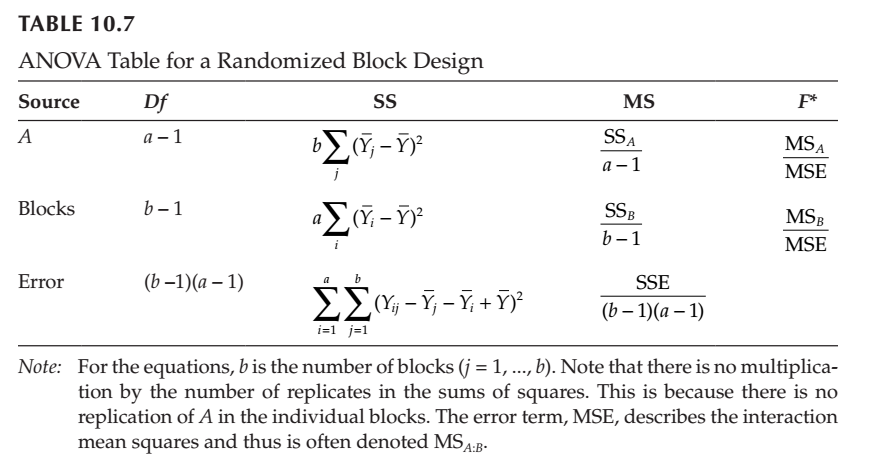

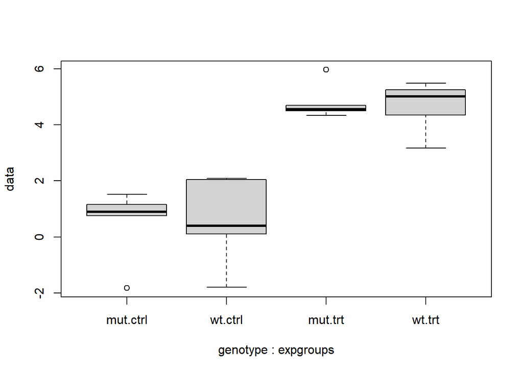

```r
boxplot(data ~ genotype + expgroups)
```

We can still look at the responses individually

```r
datalm = lm(data ~ genotype + expgroups)
summary(datalm)
```

```
##
## Call:
## lm(formula = data ~ genotype + expgroups)
##
## Residuals:
##      Min       1Q   Median       3Q      Max
## -2.37846 -0.37811  0.06745  0.65081  1.57970
##
## Coefficients:
##              Estimate Std. Error t value Pr(>|t|)
## (Intercept)   0.55435    0.44758   1.239    0.232
## genotypewt   -0.04363    0.51682  -0.084    0.934
## expgroupstrt  4.19763    0.51682   8.122 2.97e-07 ***
## ---
## Signif. codes:  0 '***' 0.001 '**' 0.01 '*' 0.05 '.' 0.1 ' ' 1
##
## Residual standard error: 1.156 on 17 degrees of freedom
## Multiple R-squared:  0.7951, Adjusted R-squared:  0.771
## F-statistic: 32.99 on 2 and 17 DF,  p-value: 1.405e-06
```

```r
summary(aov(data ~ genotype + expgroups))
```

```
##             Df Sum Sq Mean Sq F value   Pr(>F)
## genotype     1   0.01    0.01   0.007    0.934
## expgroups    1  88.10   88.10  65.968 2.97e-07 ***
## Residuals   17  22.70    1.34
## ---
## Signif. codes:  0 '***' 0.001 '**' 0.01 '*' 0.05 '.' 0.1 ' ' 1
```

### We can also just look at the interaction

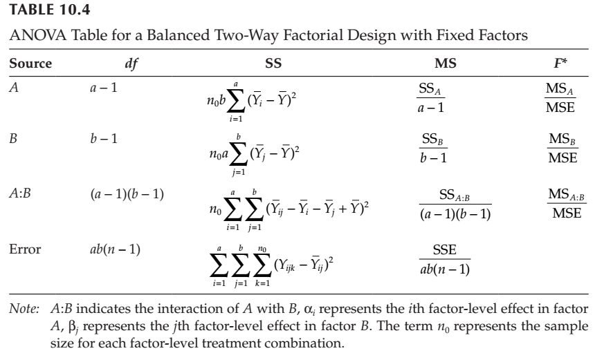

```r
datalm = lm(data ~ genotype * expgroups)
summary(datalm)
```

```
##
## Call:
## lm(formula = data ~ genotype * expgroups)
##
## Residuals:
##      Min       1Q   Median       3Q      Max
## -2.36456 -0.35083  0.06745  0.70536  1.52515
##
## Coefficients:
##                         Estimate Std. Error t value Pr(>|t|)
## (Intercept)              0.49980    0.53203   0.939    0.361
## genotypewt               0.06548    0.75240   0.087    0.932
## expgroupstrt             4.30674    0.75240   5.724 3.14e-05 ***
## genotypewt:expgroupstrt -0.21821    1.06405  -0.205    0.840
## ---
## Signif. codes:  0 '***' 0.001 '**' 0.01 '*' 0.05 '.' 0.1 ' ' 1
##
## Residual standard error: 1.19 on 16 degrees of freedom
## Multiple R-squared:  0.7957, Adjusted R-squared:  0.7573
## F-statistic: 20.77 on 3 and 16 DF,  p-value: 9.181e-06
```

Here the Estimate for the interaction term `genotypewr:expgroupstrt` tells you the *change in the slopes* comparing controls vs. experimental groups in the two different genotypes. This measures the contribution of the genotype to the treatment response.

```r
summary(aov(data ~ genotype * expgroups))
```

```
##                    Df Sum Sq Mean Sq F value   Pr(>F)
## genotype            1   0.01    0.01   0.007    0.936
## expgroups           1  88.10   88.10  62.251 6.63e-07 ***
## genotype:expgroups  1   0.06    0.06   0.042    0.840
## Residuals          16  22.64    1.42
## ---
## Signif. codes:  0 '***' 0.001 '**' 0.01 '*' 0.05 '.' 0.1 ' ' 1
```

```r
TukeyHSD(aov(data ~ genotype * expgroups))
```

```
##   Tukey multiple comparisons of means
##     95% family-wise confidence level
##
## Fit: aov(formula = data ~ genotype * expgroups)
##
## $genotype
##               diff      lwr      upr     p adj
## wt-mut -0.04362549 -1.17147 1.084219 0.9356647
##
## $expgroups
##              diff      lwr      upr p adj
## trt-ctrl 4.197631 3.069786 5.325475 7e-07
##
## $`genotype:expgroups`
##                         diff       lwr      upr     p adj
## wt:ctrl-mut:ctrl  0.06548093 -2.087145 2.218107 0.9997532
## mut:trt-mut:ctrl  4.30673697  2.154111 6.459363 0.0001668
## wt:trt-mut:ctrl   4.15400505  2.001379 6.306631 0.0002461
## mut:trt-wt:ctrl   4.24125604  2.088630 6.393882 0.0001969
## wt:trt-wt:ctrl    4.08852412  1.935898 6.241150 0.0002911
## wt:trt-mut:trt   -0.15273191 -2.305358 1.999894 0.9969143
```

## What if the gene in only one variety resonds to nitrogen

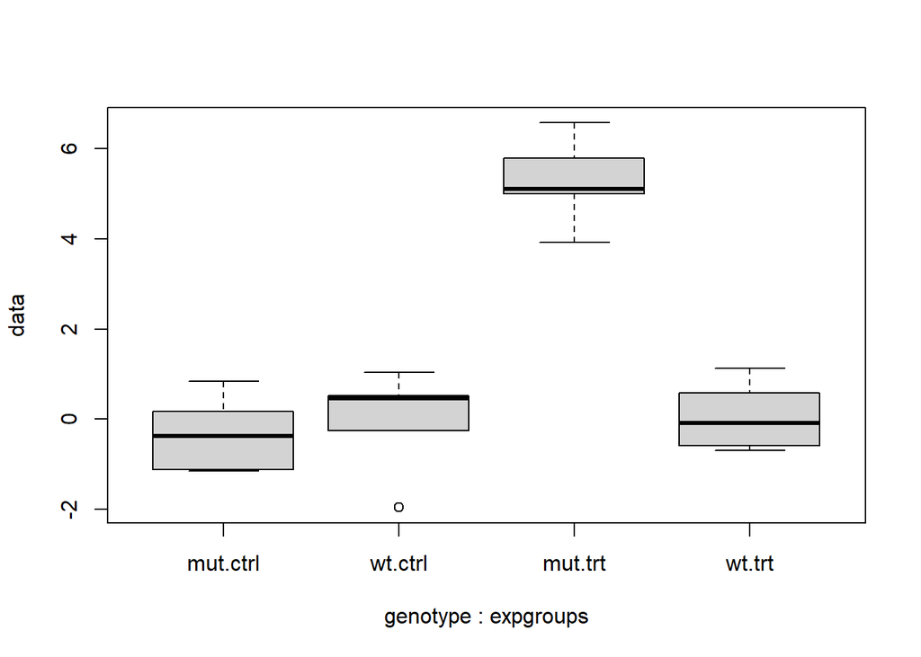

```r
wtctrl = rnorm(5,mean=0)
wttrt = rnorm(5,mean=0)

mutctrl = rnorm(5,mean=0)
muttrt = rnorm(5,mean=5)

data = c(wtctrl,wttrt,mutctrl,muttrt)
expgroups = factor(rep(c("ctrl", "trt","ctrl", "trt"), each=5))
genotype = factor(rep(c("wt", "mut"), each=10))

boxplot(data ~ genotype + expgroups)
```

```r
summary(aov(data ~ expgroups))
```

```
##             Df Sum Sq Mean Sq F value  Pr(>F)
## expgroups    1  40.78   40.78    8.86 0.00809 **
## Residuals   18  82.85    4.60
## ---
## Signif. codes:  0 '***' 0.001 '**' 0.01 '*' 0.05 '.' 0.1 ' ' 1
```

```r
summary(aov(data ~ expgroups + genotype))
```

```
##             Df Sum Sq Mean Sq F value  Pr(>F)
## expgroups    1  40.78   40.78   13.20 0.00206 **
## genotype     1  30.32   30.32    9.81 0.00607 **
## Residuals   17  52.53    3.09
## ---
## Signif. codes:  0 '***' 0.001 '**' 0.01 '*' 0.05 '.' 0.1 ' ' 1
```

Order should not matter in this case.

```r
summary(aov(data ~ genotype + expgroups))
```

```
##             Df Sum Sq Mean Sq F value  Pr(>F)
## genotype     1  30.32   30.32    9.81 0.00607 **
## expgroups    1  40.78   40.78   13.20 0.00206 **
## Residuals   17  52.53    3.09
## ---
## Signif. codes:  0 '***' 0.001 '**' 0.01 '*' 0.05 '.' 0.1 ' ' 1
```

And Tukey helps us break down the comparisons.

```r
TukeyHSD(aov(data ~ genotype + expgroups))
```

```
##   Tukey multiple comparisons of means
##     95% family-wise confidence level
##
## Fit: aov(formula = data ~ genotype + expgroups)
##
## $genotype
##             diff       lwr        upr     p adj
## wt-mut -2.462358 -4.120996 -0.8037207 0.0060711
##
## $expgroups
##              diff      lwr      upr     p adj
## trt-ctrl 2.855941 1.197303 4.514578 0.0020571
```

Using the *+* between the factors we are not paying attention to the fact that there is an interaction between the varieties and amount of nitrogen. We can do this by using a * between the factors or add a term with both factors with a *:* between them.

```r
datalm = lm(data ~ genotype * expgroups)
summary(datalm)
```

```
##
## Call:
## lm(formula = data ~ genotype * expgroups)
##
## Residuals:
##     Min      1Q  Median      3Q     Max
## -1.9212 -0.6829 -0.1038  0.5293  1.2999
##
## Coefficients:
##                         Estimate Std. Error t value Pr(>|t|)
## (Intercept)              -0.3271     0.4291  -0.762    0.457
## genotypewt                0.2872     0.6069   0.473    0.642
## expgroupstrt              5.6055     0.6069   9.236 8.20e-08 ***
## genotypewt:expgroupstrt  -5.4991     0.8583  -6.407 8.68e-06 ***
## ---
## Signif. codes:  0 '***' 0.001 '**' 0.01 '*' 0.05 '.' 0.1 ' ' 1
##
## Residual standard error: 0.9596 on 16 degrees of freedom
## Multiple R-squared:  0.8808, Adjusted R-squared:  0.8585
## F-statistic: 39.42 on 3 and 16 DF,  p-value: 1.284e-07
```

```r
datalm = lm(data ~ expgroups + genotype + genotype:expgroups)
summary(datalm)
```

```
##
## Call:
## lm(formula = data ~ expgroups + genotype + genotype:expgroups)
##
## Residuals:
##     Min      1Q  Median      3Q     Max
## -1.9212 -0.6829 -0.1038  0.5293  1.2999
##
## Coefficients:
##                         Estimate Std. Error t value Pr(>|t|)
## (Intercept)              -0.3271     0.4291  -0.762    0.457
## expgroupstrt              5.6055     0.6069   9.236 8.20e-08 ***
## genotypewt                0.2872     0.6069   0.473    0.642
## expgroupstrt:genotypewt  -5.4991     0.8583  -6.407 8.68e-06 ***
## ---
## Signif. codes:  0 '***' 0.001 '**' 0.01 '*' 0.05 '.' 0.1 ' ' 1
##
## Residual standard error: 0.9596 on 16 degrees of freedom
## Multiple R-squared:  0.8808, Adjusted R-squared:  0.8585
## F-statistic: 39.42 on 3 and 16 DF,  p-value: 1.284e-07
```

Let’s see how the summary.aov changes the results.

```r
summary(aov(data ~ genotype * expgroups))
```

```
##                    Df Sum Sq Mean Sq F value   Pr(>F)
## genotype            1  30.32   30.32   32.92 3.05e-05 ***
## expgroups           1  40.78   40.78   44.29 5.53e-06 ***
## genotype:expgroups  1  37.80   37.80   41.05 8.68e-06 ***
## Residuals          16  14.73    0.92
## ---
## Signif. codes:  0 '***' 0.001 '**' 0.01 '*' 0.05 '.' 0.1 ' ' 1
```

```r
TukeyHSD(aov(data ~ genotype * expgroups))
```

```
##   Tukey multiple comparisons of means
##     95% family-wise confidence level
##
## Fit: aov(formula = data ~ genotype * expgroups)
##
## $genotype
##             diff       lwr       upr    p adj
## wt-mut -2.462358 -3.372092 -1.552624 3.05e-05
##
## $expgroups
##              diff      lwr      upr   p adj
## trt-ctrl 2.855941 1.946207 3.765675 5.5e-06
##
## $`genotype:expgroups`
##                        diff       lwr       upr     p adj
## wt:ctrl-mut:ctrl  0.2871971 -1.449139  2.023533 0.9639029
## mut:trt-mut:ctrl  5.6054963  3.869160  7.341832 0.0000005
## wt:trt-mut:ctrl   0.3935826 -1.342754  2.129919 0.9145296
## mut:trt-wt:ctrl   5.3182991  3.581963  7.054635 0.0000009
## wt:trt-wt:ctrl    0.1063855 -1.629951  1.842722 0.9980037
## wt:trt-mut:trt   -5.2119136 -6.948250 -3.475577 0.0000012
```

### Relevel

However, in the lm() models, it is all relative to the first levels ( which are simply picked alphabetically) let’s relevel the factor and make sure wt is being used as the reference.

```r
genotype = relevel(genotype, "wt")
datalm = lm(data ~ expgroups * genotype)
summary(datalm)
```

```
##
## Call:
## lm(formula = data ~ expgroups * genotype)
##
## Residuals:
##     Min      1Q  Median      3Q     Max
## -1.9212 -0.6829 -0.1038  0.5293  1.2999
##
## Coefficients:
##                          Estimate Std. Error t value Pr(>|t|)
## (Intercept)              -0.03989    0.42914  -0.093    0.927
## expgroupstrt              0.10639    0.60689   0.175    0.863
## genotypemut              -0.28720    0.60689  -0.473    0.642
## expgroupstrt:genotypemut  5.49911    0.85828   6.407 8.68e-06 ***
## ---
## Signif. codes:  0 '***' 0.001 '**' 0.01 '*' 0.05 '.' 0.1 ' ' 1
##
## Residual standard error: 0.9596 on 16 degrees of freedom
## Multiple R-squared:  0.8808, Adjusted R-squared:  0.8585
## F-statistic: 39.42 on 3 and 16 DF,  p-value: 1.284e-07
```

Notice that the treatment is no longer significant, because in **wt** it isn’t.

Where as when perform the aov function,

```r
summary(aov(data ~ genotype * expgroups))
```

```
##                    Df Sum Sq Mean Sq F value   Pr(>F)
## genotype            1  30.32   30.32   32.92 3.05e-05 ***
## expgroups           1  40.78   40.78   44.29 5.53e-06 ***
## genotype:expgroups  1  37.80   37.80   41.05 8.68e-06 ***
## Residuals          16  14.73    0.92
## ---
## Signif. codes:  0 '***' 0.001 '**' 0.01 '*' 0.05 '.' 0.1 ' ' 1
```

```r
TukeyHSD(aov(data ~ genotype * expgroups))
```

```
##   Tukey multiple comparisons of means
##     95% family-wise confidence level
##
## Fit: aov(formula = data ~ genotype * expgroups)
##
## $genotype
##            diff      lwr      upr    p adj
## mut-wt 2.462358 1.552624 3.372092 3.05e-05
##
## $expgroups
##              diff      lwr      upr   p adj
## trt-ctrl 2.855941 1.946207 3.765675 5.5e-06
##
## $`genotype:expgroups`
##                        diff       lwr      upr     p adj
## mut:ctrl-wt:ctrl -0.2871971 -2.023533 1.449139 0.9639029
## wt:trt-wt:ctrl    0.1063855 -1.629951 1.842722 0.9980037
## mut:trt-wt:ctrl   5.3182991  3.581963 7.054635 0.0000009
## wt:trt-mut:ctrl   0.3935826 -1.342754 2.129919 0.9145296
## mut:trt-mut:ctrl  5.6054963  3.869160 7.341832 0.0000005
## mut:trt-wt:trt    5.2119136  3.475577 6.948250 0.0000012
```

### Model Simplification

As a general rule you want to only consider the more complex model if there is a significant difference between the models. We can also compare different models.

```r
dataalm1 = lm(data ~ genotype + expgroups)

dataalm2 = lm(data ~ genotype + expgroups + genotype:expgroups)

anova(dataalm1, dataalm2)
```

```
## Analysis of Variance Table
##
## Model 1: data ~ genotype + expgroups
## Model 2: data ~ genotype + expgroups + genotype:expgroups
##   Res.Df    RSS Df Sum of Sq      F    Pr(>F)
## 1     17 52.533
## 2     16 14.733  1      37.8 41.051 8.678e-06 ***
## ---
## Signif. codes:  0 '***' 0.001 '**' 0.01 '*' 0.05 '.' 0.1 ' ' 1
```

Since there is a significant difference, we keep the more complex model.